# Exploring the Central Limit Theorem

Unit 3 / Lesson 3 / Project 7

```python
import numpy as np
import pandas as pd
import scipy
import matplotlib.pyplot as plt
%matplotlib inline
```

### Scenario 1

Popuation probabilities = 0.2 and 0.5 Sample sizes = 100 , 100 Sample sizes = 1000 , 1000  
Sample sizes = 20 , 20

Observe the mean and standard deviation.

Expecations:  
With the increase in sample size I would expect the precision of the mean and standard deviation to increase. And with a decrease in sample size a decrease in precision will result.

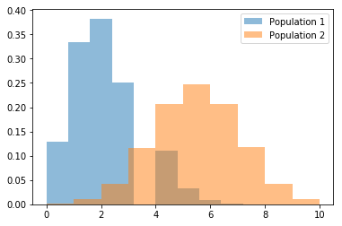

```python
n1 = 10
n2 = 10
p1 = 0.2
p2 = 0.5

pop1 = np.random.binomial(n1, p1, 10000)
pop2 = np.random.binomial(n2,p2, 10000)

plt.hist(pop1, density = True, alpha=0.5, label='Population 1')
plt.hist(pop2, density = True, alpha=0.5, label='Population 2')
plt.legend()
plt.show()
```

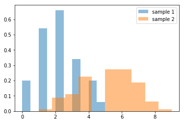

```python
sample1 = np.random.choice(pop1, 100, replace = True)
sample2 = np.random.choice(pop2, 100, replace = True)

plt.hist(sample1, density = True, alpha=0.5, label='sample 1')
plt.hist(sample2, density = True, alpha=0.5, label='sample 2')
plt.legend()
plt.show()
```

```python
print(sample1.mean())
print(sample2.mean())
print(sample1.std())
print(sample2.std())
```

```
1.99
5.1
1.2287798826478238
1.6583123951777
```

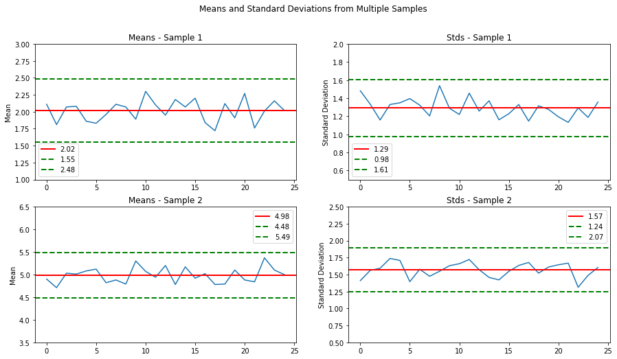

```python
sample_means_1 = [np.random.choice(pop1, 100, replace = True).mean() for i in range(25)]
sample_stds_1 = [np.random.choice(pop1, 100, replace = True).std() for i in range(25)]
sample_means_2 = [np.random.choice(pop2, 100, replace = True).mean() for i in range(25)]
sample_stds_2 = [np.random.choice(pop2, 100, replace = True).std() for i in range(25)]

plt.figure(figsize=(15, 8))
plt.subplot(2,2,1)
plt.plot(sample_means_1)
plt.ylim(1.0, 3.0)
plt.axhline(np.mean(sample_means_1), label = np.round(np.mean(sample_means_1),2), color='red',\
                                                      linestyle='solid', linewidth=2)
plt.axhline(np.mean(sample_means_1) - 3*(np.std(sample_means_1)), \
            label = np.round(np.mean(sample_means_1) - 3*(np.std(sample_means_1)),2),\
            color = 'green', linestyle = 'dashed', linewidth = 2)
plt.axhline(np.mean(sample_means_1) + 3*(np.std(sample_means_1)),\
            label = np.round(np.mean(sample_means_1) + 3*(np.std(sample_means_1)),2),\
            color = 'green', linestyle = 'dashed', linewidth = 2)
plt.title('Means - Sample 1')
plt.ylabel('Mean')
plt.legend()

plt.subplot(2,2,2)
plt.plot(sample_stds_1)
plt.ylim(0.5, 2.0)
plt.axhline(np.mean(sample_stds_1), label = np.round(np.mean(sample_stds_1),2), color='red',\
                                                      linestyle='solid', linewidth=2)
plt.axhline(np.mean(sample_stds_1) - 3*(np.std(sample_stds_1)), \
            label = np.round(np.mean(sample_stds_1) - 3*(np.std(sample_stds_1)),2),\
            color = 'green', linestyle = 'dashed', linewidth = 2)
plt.axhline(np.mean(sample_stds_1) + 3*(np.std(sample_stds_1)),\
            label = np.round(np.mean(sample_stds_1) + 3*(np.std(sample_stds_1)),2),\
            color = 'green', linestyle = 'dashed', linewidth = 2)
plt.title('Stds - Sample 1')
plt.ylabel('Standard Deviation')
plt.legend()

plt.subplot(2,2,3)
plt.plot(sample_means_2)
plt.ylim(3.5, 6.5)
plt.axhline(np.mean(sample_means_2), label = np.round(np.mean(sample_means_2),2), color='red',\
                                                      linestyle='solid', linewidth=2)
plt.axhline(np.mean(sample_means_2) - 3*(np.std(sample_means_2)), \
            label = np.round(np.mean(sample_means_2) - 3*(np.std(sample_means_2)),2),\
            color = 'green', linestyle = 'dashed', linewidth = 2)
plt.axhline(np.mean(sample_means_2) + 3*(np.std(sample_means_2)),\
            label = np.round(np.mean(sample_means_2) + 3*(np.std(sample_means_2)),2),\
            color = 'green', linestyle = 'dashed', linewidth = 2)
plt.title('Means - Sample 2')
plt.ylabel('Mean')
plt.legend()

plt.subplot(2,2,4)
plt.plot(sample_stds_2)
plt.ylim(0.5, 2.5)
plt.axhline(np.mean(sample_stds_2), label = np.round(np.mean(sample_stds_2),2), color='red',\
                                                      linestyle='solid', linewidth=2)
plt.axhline(np.mean(sample_stds_2) - 3*(np.std(sample_stds_2)), \
            label = np.round(np.mean(sample_stds_2) - 3*(np.std(sample_stds_2)),2),\
            color = 'green', linestyle = 'dashed', linewidth = 2)
plt.axhline(np.mean(sample_stds_2) + 3*(np.std(sample_stds_2)),\
            label = np.round(np.mean(sample_stds_2) + 3*(np.std(sample_means_2)),2),\
            color = 'green', linestyle = 'dashed', linewidth = 2)
plt.title('Stds - Sample 2')
plt.ylabel('Standard Deviation')
plt.legend()

plt.suptitle('Means and Standard Deviations from Multiple Samples')
plt.show()
```

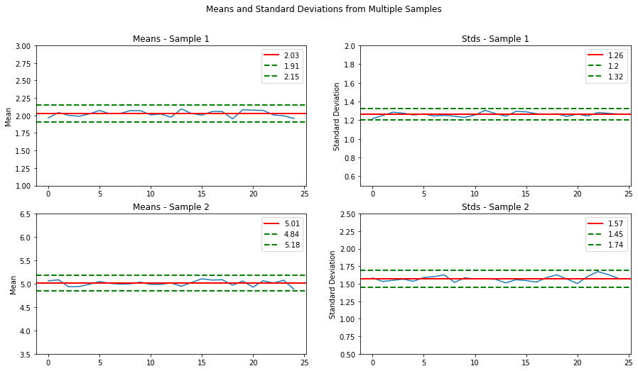

```python
sample_means_1 = [np.random.choice(pop1, 1000, replace = True).mean() for i in range(25)]
sample_stds_1 = [np.random.choice(pop1, 1000, replace = True).std() for i in range(25)]
sample_means_2 = [np.random.choice(pop2, 1000, replace = True).mean() for i in range(25)]
sample_stds_2 = [np.random.choice(pop2, 1000, replace = True).std() for i in range(25)]

plt.figure(figsize=(15, 8))
plt.subplot(2,2,1)
plt.plot(sample_means_1)
plt.ylim(1.0, 3.0)
plt.axhline(np.mean(sample_means_1), label = np.round(np.mean(sample_means_1),2), color='red',\
                                                      linestyle='solid', linewidth=2)
plt.axhline(np.mean(sample_means_1) - 3*(np.std(sample_means_1)), \
            label = np.round(np.mean(sample_means_1) - 3*(np.std(sample_means_1)),2),\
            color = 'green', linestyle = 'dashed', linewidth = 2)
plt.axhline(np.mean(sample_means_1) + 3*(np.std(sample_means_1)),\
            label = np.round(np.mean(sample_means_1) + 3*(np.std(sample_means_1)),2),\
            color = 'green', linestyle = 'dashed', linewidth = 2)
plt.title('Means - Sample 1')
plt.ylabel('Mean')
plt.legend()

plt.subplot(2,2,2)
plt.plot(sample_stds_1)
plt.ylim(0.5, 2.0)
plt.axhline(np.mean(sample_stds_1), label = np.round(np.mean(sample_stds_1),2), color='red',\
                                                      linestyle='solid', linewidth=2)
plt.axhline(np.mean(sample_stds_1) - 3*(np.std(sample_stds_1)), \
            label = np.round(np.mean(sample_stds_1) - 3*(np.std(sample_stds_1)),2),\
            color = 'green', linestyle = 'dashed', linewidth = 2)
plt.axhline(np.mean(sample_stds_1) + 3*(np.std(sample_stds_1)),\
            label = np.round(np.mean(sample_stds_1) + 3*(np.std(sample_stds_1)),2),\
            color = 'green', linestyle = 'dashed', linewidth = 2)
plt.title('Stds - Sample 1')
plt.ylabel('Standard Deviation')
plt.legend()

plt.subplot(2,2,3)
plt.plot(sample_means_2)
plt.ylim(3.5, 6.5)
plt.axhline(np.mean(sample_means_2), label = np.round(np.mean(sample_means_2),2), color='red',\
                                                      linestyle='solid', linewidth=2)
plt.axhline(np.mean(sample_means_2) - 3*(np.std(sample_means_2)), \
            label = np.round(np.mean(sample_means_2) - 3*(np.std(sample_means_2)),2),\
            color = 'green', linestyle = 'dashed', linewidth = 2)
plt.axhline(np.mean(sample_means_2) + 3*(np.std(sample_means_2)),\
            label = np.round(np.mean(sample_means_2) + 3*(np.std(sample_means_2)),2),\
            color = 'green', linestyle = 'dashed', linewidth = 2)
plt.title('Means - Sample 2')
plt.ylabel('Mean')
plt.legend()

plt.subplot(2,2,4)
plt.plot(sample_stds_2)
plt.ylim(0.5, 2.5)
plt.axhline(np.mean(sample_stds_2), label = np.round(np.mean(sample_stds_2),2), color='red',\
                                                      linestyle='solid', linewidth=2)
plt.axhline(np.mean(sample_stds_2) - 3*(np.std(sample_stds_2)), \
            label = np.round(np.mean(sample_stds_2) - 3*(np.std(sample_stds_2)),2),\
            color = 'green', linestyle = 'dashed', linewidth = 2)
plt.axhline(np.mean(sample_stds_2) + 3*(np.std(sample_stds_2)),\
            label = np.round(np.mean(sample_stds_2) + 3*(np.std(sample_means_2)),2),\
            color = 'green', linestyle = 'dashed', linewidth = 2)
plt.title('Stds - Sample 2')
plt.ylabel('Standard Deviation')
plt.legend()

plt.suptitle('Means and Standard Deviations from Multiple Samples')
plt.show()
```

Sample sized increase, precision increased.

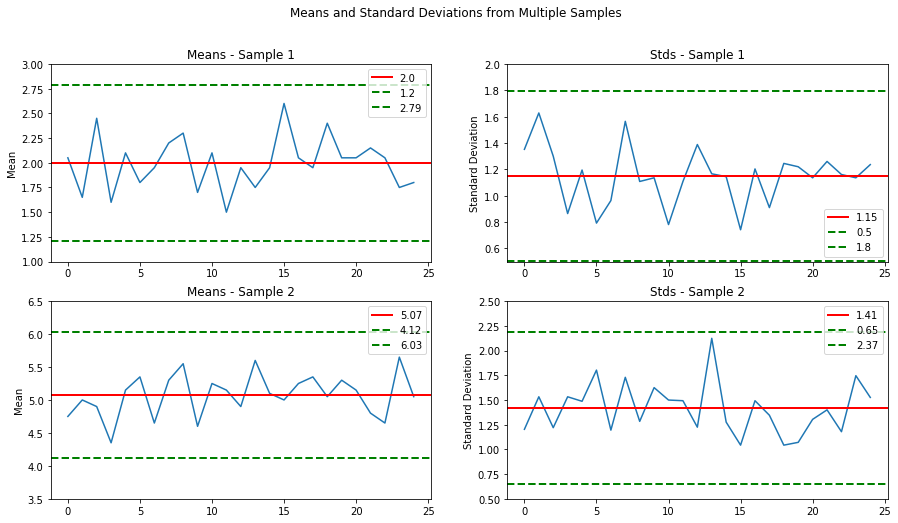

```python
sample_means_1 = [np.random.choice(pop1, 20, replace = True).mean() for i in range(25)]
sample_stds_1 = [np.random.choice(pop1, 20, replace = True).std() for i in range(25)]
sample_means_2 = [np.random.choice(pop2, 20, replace = True).mean() for i in range(25)]
sample_stds_2 = [np.random.choice(pop2, 20, replace = True).std() for i in range(25)]

plt.figure(figsize=(15, 8))
plt.subplot(2,2,1)
plt.plot(sample_means_1)
plt.ylim(1.0, 3.0)
plt.axhline(np.mean(sample_means_1), label = np.round(np.mean(sample_means_1),2), color='red',\
                                                      linestyle='solid', linewidth=2)
plt.axhline(np.mean(sample_means_1) - 3*(np.std(sample_means_1)), \
            label = np.round(np.mean(sample_means_1) - 3*(np.std(sample_means_1)),2),\
            color = 'green', linestyle = 'dashed', linewidth = 2)
plt.axhline(np.mean(sample_means_1) + 3*(np.std(sample_means_1)),\
            label = np.round(np.mean(sample_means_1) + 3*(np.std(sample_means_1)),2),\
            color = 'green', linestyle = 'dashed', linewidth = 2)
plt.title('Means - Sample 1')
plt.ylabel('Mean')
plt.legend()

plt.subplot(2,2,2)
plt.plot(sample_stds_1)
plt.ylim(0.5, 2.0)
plt.axhline(np.mean(sample_stds_1), label = np.round(np.mean(sample_stds_1),2), color='red',\
                                                      linestyle='solid', linewidth=2)
plt.axhline(np.mean(sample_stds_1) - 3*(np.std(sample_stds_1)), \
            label = np.round(np.mean(sample_stds_1) - 3*(np.std(sample_stds_1)),2),\
            color = 'green', linestyle = 'dashed', linewidth = 2)
plt.axhline(np.mean(sample_stds_1) + 3*(np.std(sample_stds_1)),\
            label = np.round(np.mean(sample_stds_1) + 3*(np.std(sample_stds_1)),2),\
            color = 'green', linestyle = 'dashed', linewidth = 2)
plt.title('Stds - Sample 1')
plt.ylabel('Standard Deviation')
plt.legend()

plt.subplot(2,2,3)
plt.plot(sample_means_2)
plt.ylim(3.5, 6.5)
plt.axhline(np.mean(sample_means_2), label = np.round(np.mean(sample_means_2),2), color='red',\
                                                      linestyle='solid', linewidth=2)
plt.axhline(np.mean(sample_means_2) - 3*(np.std(sample_means_2)), \
            label = np.round(np.mean(sample_means_2) - 3*(np.std(sample_means_2)),2),\
            color = 'green', linestyle = 'dashed', linewidth = 2)
plt.axhline(np.mean(sample_means_2) + 3*(np.std(sample_means_2)),\
            label = np.round(np.mean(sample_means_2) + 3*(np.std(sample_means_2)),2),\
            color = 'green', linestyle = 'dashed', linewidth = 2)
plt.title('Means - Sample 2')
plt.ylabel('Mean')
plt.legend()

plt.subplot(2,2,4)
plt.plot(sample_stds_2)
plt.ylim(0.5, 2.5)
plt.axhline(np.mean(sample_stds_2), label = np.round(np.mean(sample_stds_2),2), color='red',\
                                                      linestyle='solid', linewidth=2)
plt.axhline(np.mean(sample_stds_2) - 3*(np.std(sample_stds_2)), \
            label = np.round(np.mean(sample_stds_2) - 3*(np.std(sample_stds_2)),2),\
            color = 'green', linestyle = 'dashed', linewidth = 2)
plt.axhline(np.mean(sample_stds_2) + 3*(np.std(sample_stds_2)),\
            label = np.round(np.mean(sample_stds_2) + 3*(np.std(sample_means_2)),2),\
            color = 'green', linestyle = 'dashed', linewidth = 2)
plt.title('Stds - Sample 2')
plt.ylabel('Standard Deviation')
plt.legend()

plt.suptitle('Means and Standard Deviations from Multiple Samples')
plt.show()
```

Sample size decreased, precision decreased.

### Scenario 2

Popuation probabilities = 0.2 and 0.5 Popuation probabilities = 0.3 and 0.5  
Popuation probabilities = 0.4 and 0.5  
Sample sizes = 100 , 100

Compute the t-Test.

Expecations:  
As the population probabilities converge the t-statistic will decrease the the p-value will increase.

```python
from scipy.stats import ttest_ind

n1 = 10
n2 = 10
p1 = 0.2
p2 = 0.5

pop1 = np.random.binomial(n1, p1, 10000)
pop2 = np.random.binomial(n2,p2, 10000)

sample1 = np.random.choice(pop1, 100, replace = True)
sample2 = np.random.choice(pop2, 100, replace = True)

print(ttest_ind(sample2, sample1, equal_var=False))
```

```
Ttest_indResult(statistic=16.167046082790648, pvalue=1.3086394014213975e-37)
```

```python
from scipy.stats import ttest_ind

n1 = 10
n2 = 10
p1 = 0.3
p2 = 0.5

pop1 = np.random.binomial(n1, p1, 10000)
pop2 = np.random.binomial(n2,p2, 10000)

sample1 = np.random.choice(pop1, 100, replace = True)
sample2 = np.random.choice(pop2, 100, replace = True)

print(ttest_ind(sample2, sample1, equal_var=False))
```

```
Ttest_indResult(statistic=8.657668501426757, pvalue=1.6996313015903632e-15)
```

t-Statistic has decreased and p-value hase increased.

```python
from scipy.stats import ttest_ind

n1 = 10
n2 = 10
p1 = 0.4
p2 = 0.5

pop1 = np.random.binomial(n1, p1, 10000)
pop2 = np.random.binomial(n2,p2, 10000)

sample1 = np.random.choice(pop1, 100, replace = True)
sample2 = np.random.choice(pop2, 100, replace = True)

print(ttest_ind(sample2, sample1, equal_var=False))
```

```
Ttest_indResult(statistic=5.07298196106271, pvalue=9.053959645124394e-07)
```

t-Statistic has decreased and p-value has increased.

### Scenario 3

Distributions from binomial to Poisson.

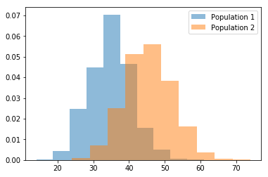

```python
c1 = 35
c2 = 45


pop1 = np.random.poisson(c1, 10000)
pop2 = np.random.poisson(c2, 10000)

plt.hist(pop1, density = True, alpha=0.5, label='Population 1')
plt.hist(pop2, density = True, alpha=0.5, label='Population 2')
plt.legend()
plt.show()
```

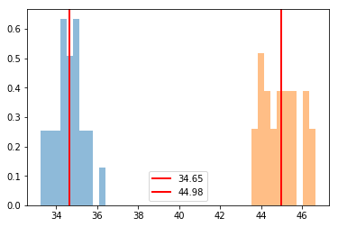

```python
sample_means_1 = [np.random.choice(pop1, 100, replace = True).mean() for i in range(25)]
sample_means_2 = [np.random.choice(pop2, 100, replace = True).mean() for i in range(25)]

plt.hist(sample_means_1, density = True, alpha=0.5)
plt.axvline(np.mean(sample_means_1), label = np.round(np.mean(sample_means_1),2), color='red',\
                                                      linestyle='solid', linewidth=2)
plt.hist(sample_means_2, density = True, alpha=0.5)
plt.axvline(np.mean(sample_means_2), label = np.round(np.mean(sample_means_2),2), color='red',\
                                                      linestyle='solid', linewidth=2)
plt.legend()
plt.show()
```

When changing from a binomial distrbution to a Poisson distribution the sample means still represent the population means. As the population mean for set 1 is 35.0 and the sample mean converges to 35. Likewise the population mean for set 2 is 45.0 and the sample mean converges to 45.